# Simple Linear Regression

2024-09-22

## 1: Title and Introduction

## (Part 1) - Simple Linear Regression

### What is Simple Linear Regression?

Simple Linear Regression is a statistical method used to understand and model the relationship between two variables:

- **One independent variable** (predictor, denoted as \(x\)).
- **One dependent variable** (response, denoted as \(y\)).

It assumes that there is a linear relationship between the two variables, which can be represented by a straight line.

## (Part 2) - Why is it Important?

Linear regression is one of the most fundamental and widely used techniques in data analysis. It helps in:

- Predicting values of the dependent variable based on the independent variable.
- Understanding the strength and nature of the relationship between the two variables.
- Making future predictions, business decisions, or solving real-world problems.

## (Part 3) - Applications

- **Finance**: Predicting stock prices based on historical data.
- **Economics**: Forecasting economic indicators such as inflation or GDP.
- **Biology**: Modeling the relationship between a drug dosage and patient recovery rate.
- **Engineering**: Estimating material strength as a function of load applied.

## 2: Definition of Simple Linear Regression

## (Part 1) - How does Simple Linear Regression Work?

Simple linear regression models the relationship between two variables by fitting a linear equation to observed data. The model tries to minimize the difference between the observed values and the values predicted by the linear equation.

## (Part 2) - Equation

The equation for Simple Linear Regression is:

\[ y = \beta_0 + \beta_1 x + \epsilon \]

Where:

- \(y\) is the **dependent variable** (what you are trying to predict).
- \(x\) is the **independent variable** (the predictor).
- \(\beta_0\) is the **intercept** (the value of \(y\) when \(x = 0\)).
- \(\beta_1\) is the **slope** (the rate of change in \(y\) for each unit increase in \(x\)).
- \(\epsilon\) is the **error term** (captures the variability in \(y\) that cannot be explained by the model).

## (Part 3) - Key Concepts

- **Intercept (\(\beta_0\))**: This is the point where the regression line crosses the y-axis. It represents the expected value of \(y\) when \(x\) is zero.
- **Slope (\(\beta_1\))**: This represents the change in the dependent variable for each one-unit change in the independent variable. A positive slope means as \(x\) increases, \(y\) increases, and vice versa.
- **Residuals**: The difference between observed values and predicted values. Residuals help assess the accuracy of the model.

## 3: Assumptions of Simple Linear Regression

## Assumptions

1. **Linearity**: The relationship between the independent variable \(x\) and the dependent variable \(y\) is linear.
2. **Independence**: Observations are independent of each other.
3. **Homoscedasticity**: The variance of residuals (errors) is constant across all values of the independent variable.
4. **Normality**: Residuals are normally distributed.
5. **No Multicollinearity**: In simple linear regression, we only have one predictor, so this assumption is naturally met.

*Understanding these assumptions is crucial because violations can lead to biased or inefficient estimates.*

## 4: Example Data (ggplot2)

## (Part 1) - Scatterplot with Linear Fit of Generated Data

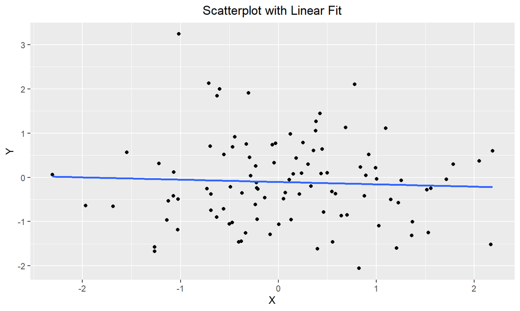

## (Part 2) - Description/Explanation

This scatterplot visualizes the relationship between the independent variable \(x\) and the dependent variable \(y\), with a fitted linear regression line. The model suggests how well the independent variable \(x\) predicts the dependent variable \(y\), capturing any linear trend in the data.

## 5: Interactive Plot (Plotly Plot)

## (Part 1) - Interactive Linear Regression Model with Plotly

[interactive chart not shown]

## (Part 2) - Description/Explanation

The interactive plot allows for dynamic exploration of the relationship between \(x\) and \(y\). You can hover over points to see the precise values and observe the linear trend, making it easier to understand the model’s behavior and predictions.

## 6: Residuals vs Fitted plot

## (Part 1) - Validating Model Assumptions: Residuals vs Fitted Plot

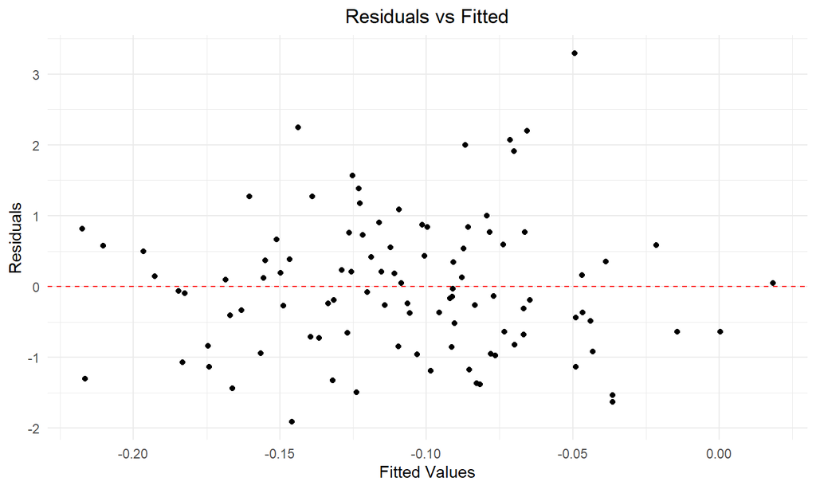

## (Part 2) - Description/Explanation

This plot is a diagnostic tool to check the assumptions of the linear regression model. The residuals, which are the differences between observed and predicted \(y\) values, should be randomly scattered around zero. This indicates that the model fits the data well, with no obvious patterns in the residuals.

## 7: ggplot2 Diagnostic Plot (Residuals Histogram)

## (Part 1) - Histogram of Model Residuals for Diagnostic Evaluation

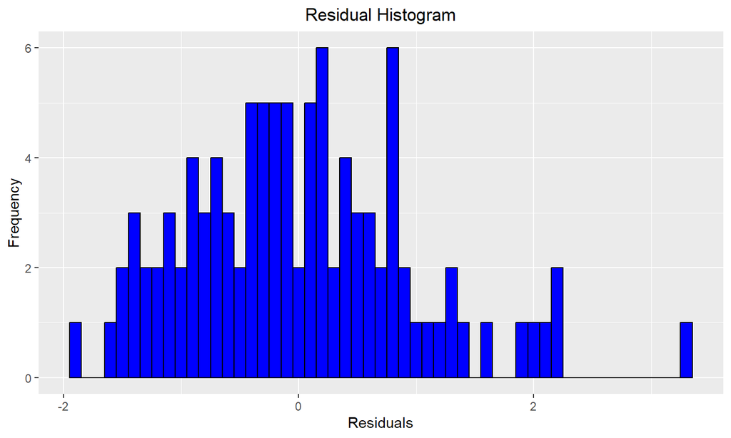

## (Part 2) - Description/Explanation

The histogram shows the distribution of residuals, which helps in assessing whether the residuals are normally distributed. A bell-shaped curve would suggest that the assumption of normality for residuals is met, an important aspect for accurate regression modeling.

## 8: Simple R Code for Linear Regression Summary

## (Part 1) - Summary of Linear Regression Model Output

```
##
## Call:
## lm(formula = y ~ x, data = data)
##
## Residuals:
##     Min      1Q  Median      3Q     Max
## -1.9073 -0.6835 -0.0875  0.5806  3.2904
##
## Coefficients:
##             Estimate Std. Error t value Pr(>|t|)
## (Intercept) -0.10280    0.09755  -1.054    0.295
## x           -0.05247    0.10688  -0.491    0.625
##
## Residual standard error: 0.9707 on 98 degrees of freedom
## Multiple R-squared:  0.002453,   Adjusted R-squared:  -0.007726
## F-statistic: 0.241 on 1 and 98 DF,  p-value: 0.6246
```

## (Part 2) - Description/Explanation

The linear model summary provides statistical insights into the relationship between \(x\) and \(y\). The coefficients, \(\beta_0\) (intercept) and \(\beta_1\) (slope), quantify the model’s predictions, while the \(R^2\) value measures the proportion of variance in \(y\) explained by \(x\). A high \(R^2\) suggests a strong linear relationship between the two variables.

## Slide 9: Conclusion

## Summary of Simple Linear Regression

- Simple Linear Regression is a foundational technique to model relationships between two variables.
- The model assumes a linear relationship, normally distributed residuals, and constant variance.
- Evaluating residuals through diagnostic plots ensures that the model fits the data appropriately.
- Linear regression serves as a basis for more complex models and helps in making predictions or identifying trends.